# Practical Machine Learning

Sudarshan Dodda

December 27,2015

## Background

Quantified Self devices are becoming more and more common, and are able to collect a large amount of data about people and their personal health activities. The focus of this project is to utilize some sample data on the quality of certain exercises to predict the manner in which they did the exercise.

## Analysis

This analysis will build a machine learning model from the sample data that is attempting to most accurately predict the manner in which the exercise was performed. This is a classification problem into discrete categories, which in the training data are located in the ‘classe’ varaible.

## Preparing the data

Load packages, set caching

```r
library(RCurl)
library(caret)
```

```r
library(corrplot)
library(ggplot2)
library(doMC)
knitr::opts_chunk$set(cache=TRUE)
```

## Getting Data

```r
# URL of the training and testing data
train.url ="https://d396qusza40orc.cloudfront.net/predmachlearn/pml-training.csv"
test.url = "https://d396qusza40orc.cloudfront.net/predmachlearn/pml-testing.csv"

x <- getURL(train.url, ssl.verifypeer = FALSE)
y<- getURL(test.url, ssl.verifypeer = FALSE)
train <- read.csv(textConnection(x))
test <- read.csv(textConnection(y))
dim(train)
```

```
## [1] 19622   160
```

```r
dim(test)
```

```
## [1]  20 160
```

Replace NA values with 999

```r
test[is.na(test)]<-999
train[is.na(train)] <- 999
```

Removing columns which has Id and Timestamp columns from both train and test

```r
train$X <- NULL
train$user_name <-NULL
train$raw_timestamp_part_1 <-NULL
train$raw_timestamp_part_2 <- NULL
train$cvtd_timestamp <- NULL

test$X <- NULL
test$user_name <-NULL
test$raw_timestamp_part_1 <-NULL
test$raw_timestamp_part_2 <- NULL
test$cvtd_timestamp <- NULL
```

Checking the factor levels in classe

```r
str(train$classe)
```

```
##  Factor w/ 5 levels "A","B","C","D",..: 1 1 1 1 1 1 1 1 1 1 ...
```

```r
levels(train$classe)
```

```
## [1] "A" "B" "C" "D" "E"
```

Assigning classe to outcome

```r
outcome <- train[,"classe"]
```

Remove ‘classe’ column from train

```r
train$classe <- NULL
```

## Preprocessing

Check for Near Zero Variance

```r
nzv.train = nearZeroVar(train, saveMetrics=TRUE)
nzv.train$nzv
```

```
##   [1]  TRUE FALSE FALSE FALSE FALSE FALSE  TRUE  TRUE  TRUE  TRUE  TRUE
##  [12]  TRUE  TRUE  TRUE  TRUE  TRUE  TRUE  TRUE  TRUE  TRUE  TRUE  TRUE
##  [23]  TRUE  TRUE  TRUE  TRUE  TRUE  TRUE  TRUE  TRUE  TRUE FALSE FALSE
##  [34] FALSE FALSE FALSE FALSE FALSE FALSE FALSE FALSE FALSE FALSE FALSE
##  [45]  TRUE  TRUE  TRUE  TRUE  TRUE  TRUE  TRUE  TRUE  TRUE  TRUE FALSE
##  [56] FALSE FALSE FALSE FALSE FALSE FALSE FALSE FALSE  TRUE  TRUE  TRUE
##  [67]  TRUE  TRUE  TRUE  TRUE  TRUE  TRUE  TRUE  TRUE  TRUE  TRUE  TRUE
##  [78]  TRUE FALSE FALSE FALSE  TRUE  TRUE  TRUE  TRUE  TRUE  TRUE  TRUE
##  [89]  TRUE  TRUE  TRUE  TRUE  TRUE  TRUE  TRUE  TRUE FALSE  TRUE  TRUE
## [100]  TRUE  TRUE  TRUE  TRUE  TRUE  TRUE  TRUE  TRUE FALSE FALSE FALSE
## [111] FALSE FALSE FALSE FALSE FALSE FALSE FALSE FALSE FALSE  TRUE  TRUE
## [122]  TRUE  TRUE  TRUE  TRUE  TRUE  TRUE  TRUE  TRUE  TRUE  TRUE  TRUE
## [133]  TRUE  TRUE FALSE  TRUE  TRUE  TRUE  TRUE  TRUE  TRUE  TRUE  TRUE
## [144]  TRUE  TRUE FALSE FALSE FALSE FALSE FALSE FALSE FALSE FALSE FALSE
```

Removing the columns which has Near Zero Variance(nzv) is TRUE from both train and test data sets

```r
train_new <- train[c(rownames(nzv.train[nzv.train$nzv ==FALSE,]))]
test_new <- test[c(rownames(nzv.train[nzv.train$nzv ==FALSE,]))]
```

## Plot of relationship between features and outcome

Plot the relationship between features and outcome. From the plot below, each features has relatively the same distribution among the 5 outcome levels (A, B, C, D, E).

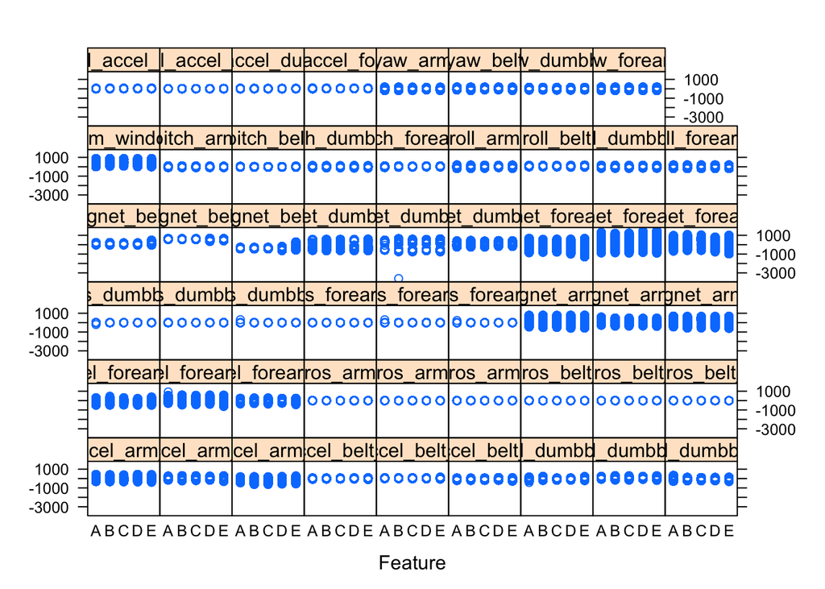

```r
featurePlot(train_new,outcome, "strip")
```

combining outcome with train_new dataset

```r
train_combined <- cbind(train_new,outcome)
```

## set random seed, for reproducibility

```r
set.seed(1234)
```

## Splitting the training data into train and validation data sets

```r
inTrain <- createDataPartition(y=train_combined$outcome,p=0.8, list=FALSE)
trainData <- train_combined[inTrain,]
validationData <- train_combined[-inTrain,]
```

```r
## set my cores
registerDoMC(cores = 8)
```

## Model Building

From repeated Cross-Validation,got the best tune parameters for n.trees,interaction.depth and shrinkage.

```r
#fitcontrol <- trainControl(method = 'repeatedcv',number = 5,repeats = 3)
fitcontrol <- trainControl(method = "none")
gbmmodel <- train(outcome ~.,data = trainData,trControl = fitcontrol,
                  tuneGrid = expand.grid(n.trees = 150,
                                         interaction.depth = 3,shrinkage = 0.1),
                                         method = 'gbm',metric="Kappa")
```

## Top 20 features

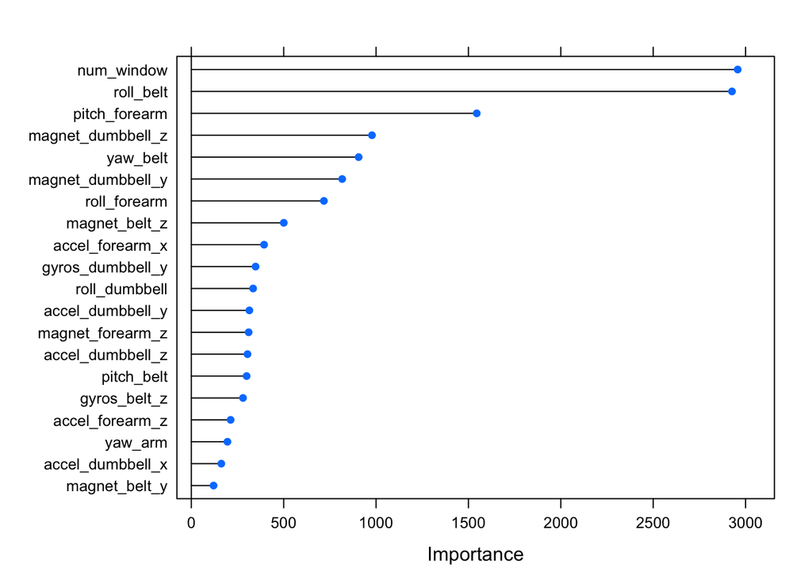

```r
gbmImp <- varImp(gbmmodel,scale = FALSE)
plot(gbmImp,top =20)
```

## Predictions

```r
predictions <- predict(object = gbmmodel,validationData)
```

## Cross-validation

```r
confusionMatrix(validationData$outcome,predictions)
```

```
## Confusion Matrix and Statistics
##
##           Reference
## Prediction    A    B    C    D    E
##          A 1116    0    0    0    0
##          B    5  745    9    0    0
##          C    0    6  677    1    0
##          D    0    3    3  635    2
##          E    2    2    0    2  715
##
## Overall Statistics
##
##                Accuracy : 0.9911
##                  95% CI : (0.9876, 0.9938)
##     No Information Rate : 0.2863
##     P-Value [Acc > NIR] : < 2.2e-16
##
##                   Kappa : 0.9887
##  Mcnemar's Test P-Value : NA
##
## Statistics by Class:
##
##                      Class: A Class: B Class: C Class: D Class: E
## Sensitivity            0.9938   0.9854   0.9826   0.9953   0.9972
## Specificity            1.0000   0.9956   0.9978   0.9976   0.9981
## Pos Pred Value         1.0000   0.9816   0.9898   0.9876   0.9917
## Neg Pred Value         0.9975   0.9965   0.9963   0.9991   0.9994
## Prevalence             0.2863   0.1927   0.1756   0.1626   0.1828
## Detection Rate         0.2845   0.1899   0.1726   0.1619   0.1823
## Detection Prevalence   0.2845   0.1935   0.1744   0.1639   0.1838
## Balanced Accuracy      0.9969   0.9905   0.9902   0.9964   0.9977
```

## Out Of Bag Error Rate

The model achieved an accuracy of 99.11% from Cross validation of Validation Data set which indicates the Out of Bag error rate 0.89%

## Final Model Testing

```r
results <- predict(gbmmodel,newdata=test_new)
#print(as.data.frame(results))
```

## Submission

```r
path = "/Users/Siddhu/Desktop/jhu_coursera/jhu_practical_machine_learning/output/"
pml_write_files = function(x) {
  n = length(x)
  for(i in 1: n) {
    filename = paste0("problem_id_", i, ".txt")
    write.table(x[i], file=file.path(path, filename),
                quote=FALSE, row.names=FALSE, col.names=FALSE)
  }
}
pml_write_files(results)
```